# Lecture 16: STUFF

STUFF

Dr. Gordon Wright

g.wright@gold.ac.uk

Mon 24 Feb, 2025

## A number of topics to cover today

With the goal of clearing the decks before Reading Week

- Thank you to everyone who contributed so wonderfully on Thursday
- Review existing materials available to you for the Mini-Dissertation
- Labs tomorrow will be focused on finalising data collection and a data audit
- CHIP topics

## Thank you

I was really pleased to see you all contribute to Thursday and the First Years are all very grateful

Some of you might have noticed that there was an extra option available to the First Years…

[figure not shown]

## Results will be announced in the last lecture!

[figure not shown]

## I just want to recap the materials available on the VLE

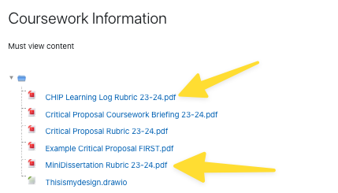

## Mini-Dissertation Writing Guides

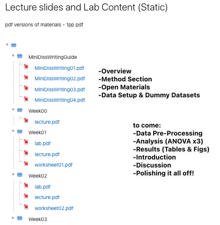

## Mini-Dissertation Resources

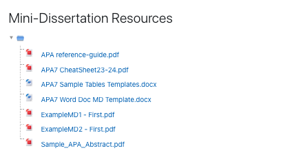

## Data Analysis

**Remember, PS52005C Design & Analysis is where you are taught ANOVA**

[figure not shown]

# Labs tomorrow

## I ask for your help

- I shall be circulating performing a data sudit
- So please turn up if you can
- Be ready to give me a status on your data collection efforts and plans for stopping
- We will decide if I need to fabricate data for you
- Please put a message on Whatsapp

# Now let’s quickly discuss CHIP

## CHIP Assignment(s)

- Coursework piece designed to allow you to engage reflexively with the ‘big picture’ of your degree
- Think about how these issues link into psychology as a discipline, and how they relate to your own thoughts about what psychology is or should be
- Two ‘reflective accounts’ of max 600 words each (Not including obligatory reference list)
- **Marks are awarded for reflection**, evidence of learning and bring topics together. Please see marking criteria for both accounts.
- Not looking for a restatement of the facts in the lectures etc.
- **They are designed to be personal and reflective – embrace this aspect!**

## Reflective Account 1

Essay 1 is based on the content of ONE of the topics and should adopt at least two of the following 6 ‘perspectives’.

- As a **STUDENT** of psychology
- As a **TRAINEE** psychologist
- In relation to a **RESEARCH** application in your future
- As an **HISTORIAN** of psychology
- Reporting on the culture or **PRACTICE** of psychology as it currently exists here or across cultures
- As a critic or supporter of psychology’s status as a **SCIENCE**

## Reflective Account 1 tips

- Ask a specific question – and answer it.
- Intro, body, conclusion structure.
- Reflect on the topic and give your own opinion as to the answer!
- Present a journey in your learning or appreciation of the topic
- Ensure your answer is argued using examples
- Use evidence in your argument from a range of sources, ideally do some strategic wider reading
- Present and reference it well

## Reflective Account 2

Essay 2 should focus on at least one of the OTHER topics covered in the course.

- This answer should focus on a primary reading and then any further reading you have done (strongly encouraged).
- You must identify that primary reading explicitly in the essay itself.
- You should not simply restate what the authors thought or found, but rather briefly summarise and build
- Think about your perspective on the issues.
- What do you think about this debate or issue? We want to know!
- And what do you think are interesting directions for psychologists to take this debate or issue in the future?

## Reflective Account 2 tips

- Explicitly identify a single initial reading and build upon that.
- Discuss a debate or issue that you think is interesting or important
- Give your own opinion and how this has developed or changed as a result of the lecture, the course more widely, and/or the reading.
- Argue your opinion explicitly, own it and back it up with examples
- Use evidence in your argument from a range of sources, ideally do some strategic wider reading
- Present and reference it well

## Overlapping content

- You can combine across different topics in Essay 2 (e.g., you could talk about Evolution and Consciousness, or Inclusivity and Science), and thinking about links between topics is strongly encouraged.
- However, the material covered in Essay 2 must be different from Essay 1. Students will be penalised for covering identical topics.

## Is this a CHIP-able topic?

# Any Questions?

[figure not shown]

Research Methods Lecture 16